# 市场观察

2017/02/17

## A、指数估值

### (a)动态市盈率、市净率

核心指数成分股近18个月的动态市盈率及动态市净率中位数走势如下图所示：

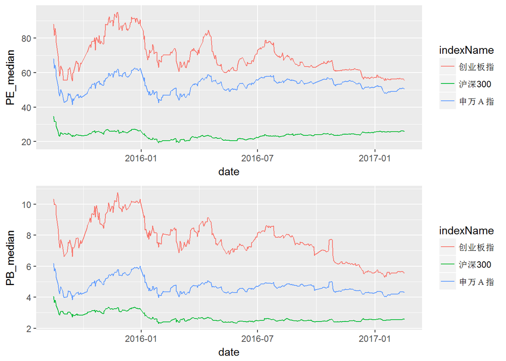

### (b)动态市盈率、市净率百分位

核心指数近18个月的动态市盈率百分位及动态市净率百分位走势如下图所示：

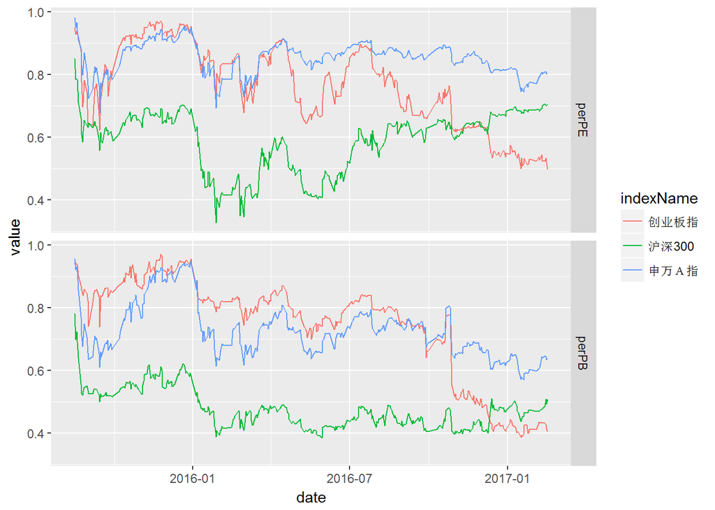

### (c)指数估值概览

| 日期 | 指数代码 | 指数简称 | 动态市盈率 | 市盈率百分位 | 动态市净率 | 市净率百分位 |
| --- | --- | --- | --- | --- | --- | --- |
| 2017-02-16 | EI000979 | 大宗商品 | 57.2 | 98.5% | 3.0 | 74.5% |
| 2017-02-16 | EI000819 | 有色金属 | 60.8 | 84.6% | 3.9 | 80.2% |
| 2017-02-16 | EI801003 | 申万Ａ指 | 50.7 | 80.3% | 4.3 | 63.9% |
| 2017-02-16 | EI000827 | 中证环保 | 44.2 | 78.1% | 3.2 | 32.5% |
| 2017-02-16 | EI000300 | 沪深300 | 26.2 | 70.7% | 2.6 | 50.8% |
| 2017-02-16 | EI399005 | 中小板指P | 42.2 | 68.2% | 4.8 | 47.3% |
| 2017-02-16 | EI399330 | 深证100 | 32.7 | 67.4% | 3.9 | 59.6% |
| 2017-02-16 | EI000905 | 中证500 | 40.5 | 67.0% | 3.2 | 40.9% |
| 2017-02-16 | EI399959 | 军工指数 | 85.1 | 63.5% | 5.4 | 67.6% |
| 2017-02-16 | EI000933 | 中证医药 | 39.2 | 62.9% | 3.9 | 6.2% |
| 2017-02-16 | EI000016 | 上证50 | 17.8 | 61.1% | 1.7 | 19.4% |
| 2017-02-16 | EI000934 | 中证金融 | 18.8 | 60.9% | 2.0 | 30.5% |
| 2017-02-16 | EI399006 | 创业板指 | 55.4 | 49.8% | 5.5 | 40.6% |
| 2017-02-16 | EI000998 | 中证TMT | 42.9 | 44.8% | 4.3 | 39.4% |
| 2017-02-16 | EI000932 | 中证消费 | 29.9 | 31.8% | 3.8 | 21.8% |

## B、基差

### (a)基差走势

三大股指期货合约基差走势如下图，其中当月合约和次月合约年化基差百分比波动较大，仅展示合约基差百分比，当季合约和次季合约展示基差年化百分比：

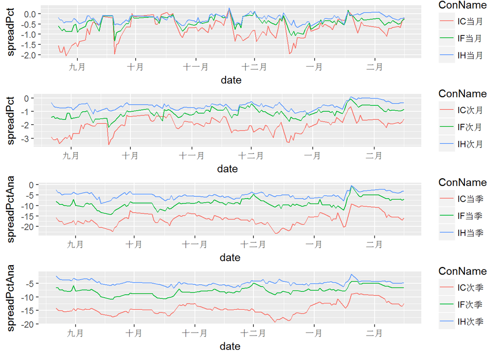

### (b)基差概况

三大股指期货连续合约基差概况如下表，近月合约临近到期日，年化基差百分比数据波动较大：

| 日期 | 合约代码 | 合约收盘价 | 指数收盘价 | 基差 | 基差百分比 | 年化基差百分比 |
| --- | --- | --- | --- | --- | --- | --- |
| 2017-02-16 | IC1702 | 6345.0 | 6359.34 | -14.34 | -0.23% | -127% |
| 2017-02-16 | IC1703 | 6260.4 | 6359.34 | -98.94 | -1.56% | -21% |
| 2017-02-16 | IC1706 | 6045.0 | 6359.34 | -314.34 | -4.94% | -16% |
| 2017-02-16 | IC1709 | 5917.0 | 6359.34 | -442.34 | -6.96% | -12% |
| 2017-02-16 | IF1702 | 3432.4 | 3440.93 | -8.53 | -0.25% | -147% |
| 2017-02-16 | IF1703 | 3411.8 | 3440.93 | -29.13 | -0.85% | -11% |
| 2017-02-16 | IF1706 | 3363.8 | 3440.93 | -77.13 | -2.24% | -7% |
| 2017-02-16 | IF1709 | 3310.6 | 3440.93 | -130.33 | -3.79% | -7% |
| 2017-02-16 | IH1702 | 2372.2 | 2376.76 | -4.56 | -0.19% | -101% |
| 2017-02-16 | IH1703 | 2368.2 | 2376.76 | -8.56 | -0.36% | -5% |
| 2017-02-16 | IH1706 | 2352.0 | 2376.76 | -24.76 | -1.04% | -3% |
| 2017-02-16 | IH1709 | 2312.8 | 2376.76 | -63.96 | -2.69% | -5% |

## C、套利和事件

### (a)复牌股票套利

近两天复牌股票套利情况如下表：

[1] “无复牌股票套利”

### (b)定增基金(provided by han.qian)

截止2017-02-17定增基金数据如下表，明细数据参见钱瀚的模板。

| 代码 | 名称 | 到期日期 | 最新净值 | 昨日收盘价 | 折溢价率 | 整体隐含折价率 | 大盘下跌0.1净值变化 |
| --- | --- | --- | --- | --- | --- | --- | --- |
| 168101.OF | 九泰锐智 | 20200814 | 1.19 | 1.10 | -7.3% | 5.6% | -8.3% |
| 168102.OF | 九泰锐富 | 20210204 | 1.03 | 0.94 | -9.4% | 4.2% | -4.3% |
| 501015.OF | 财通升级 | 20170908 | 1.05 | 1.01 | -3.4% | 4.7% | -7.9% |
| 160518.OF | 博时睿远 | 20171016 | 0.99 | 0.95 | -3.8% | 2.8% | -5.5% |

定增基金近期的净值走势如下图：

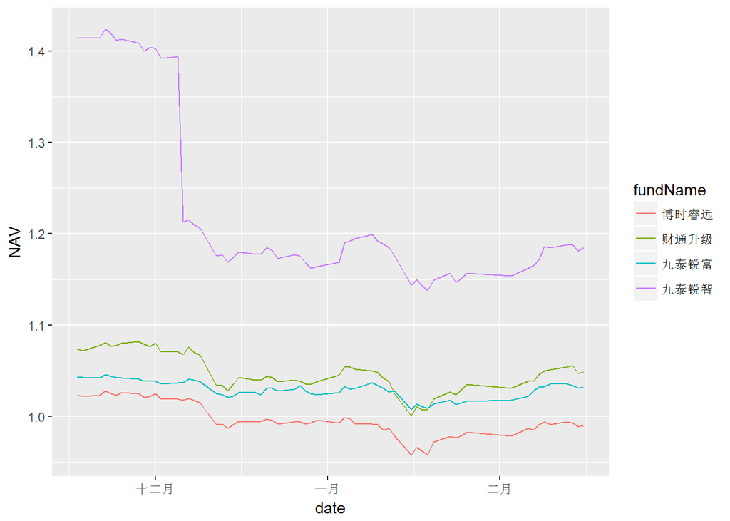

定增基金近期的折溢价率百分比走势如下图：

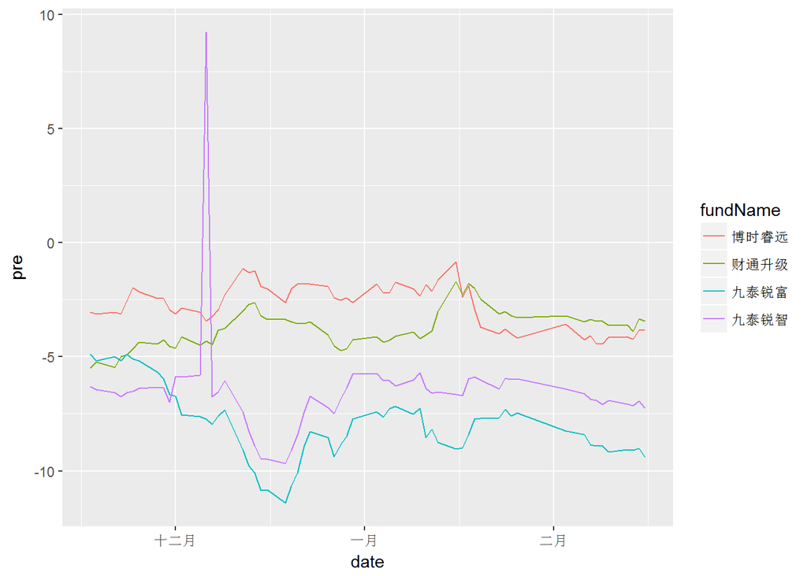

### (c)定增解禁(provided by han.qian)

近十天定增解禁的股票情况如下表。

| 股票代码 | 股票简称 | 跟踪起始日 | 解禁日 | 区间涨跌幅 | 所属行业指数 | 行业指数涨跌幅 |
| --- | --- | --- | --- | --- | --- | --- |
| EQ000723 | 美锦能源 | 2017-02-03 | 2017-02-17 | 3.97% | 申万采掘 | 3.54% |
| EQ300419 | 浩丰科技 | 2017-02-03 | 2017-02-17 | -1.84% | 申万纺织服装 | 1.88% |
| EQ002252 | 上海莱士 | 2017-02-06 | 2017-02-20 | -3.44% | 申万农林牧渔 | 0.22% |
| EQ600438 | 通威股份 | 2017-02-06 | 2017-02-20 | -1.29% | 申万化工 | 1.92% |
| EQ600756 | 浪潮软件 | 2017-02-06 | 2017-02-20 | -2.97% | 申万汽车 | 0.43% |
| EQ600784 | 鲁银投资 | 2017-02-06 | 2017-02-20 | 8.23% | 申万计算机 | 0.13% |
| EQ600369 | 西南证券 | 2017-02-10 | 2017-02-24 | -0.29% | 申万医药生物 | -0.16% |
| EQ600785 | 新华百货 | 2017-02-10 | 2017-02-24 | -1.27% | 申万非银金融 | 1.13% |
| EQ000701 | 厦门信达 | 2017-02-13 | 2017-02-27 | -0.27% | 申万电子 | 0.70% |
| EQ002513 | *ST 蓝丰 | 2017-02-13 | 2017-02-27 | 0.40% | 申万计算机 | -0.12% |
| EQ002590 | 万安科技 | 2017-02-14 | 2017-02-28 | -1.17% | 申万商业贸易 | 0.19% |
| EQ601599 | 鹿港文化 | 2017-02-17 | 2017-03-03 | 0.00% | 申万钢铁 | 0.00% |

## D、择时

### (a)等权指数

从历史来看，A股市场存在小盘股效应，市值小的股票长期整体跑赢大市值的股票，美股市场同样存在类似的现象。而目前大部分指数的编制方案都是类似市值加权，为了抛去市值的影响，下面展示几个等权指数，其中中证500等权和沪深300等权是现有的指数，中证全指等权是自己编制的指数。等权指数可以视为一个更好地业绩比较基准。等权指数走势如下图：

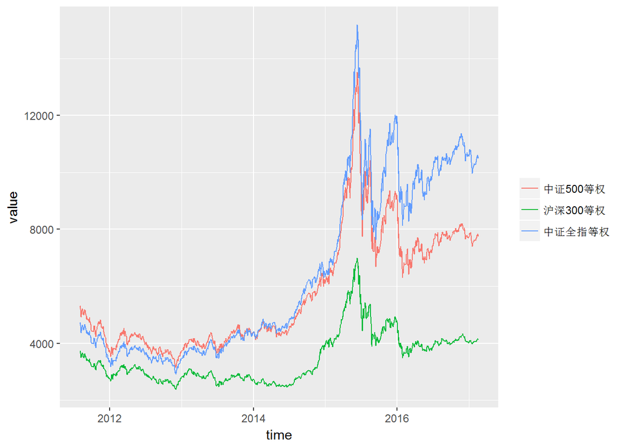

等权指数收益率统计见下表：

|  | 中证500等权 | 沪深300等权 | 中证全指等权 |
| --- | --- | --- | --- |
| 2011-08-02 ~ 2011-12-30 | -29.2% | -25.5% | -27.8% |
| 2012-01-04 ~ 2012-12-31 | -0.0% | 1.5% | 2.3% |
| 2013-01-04 ~ 2013-12-31 | 16.7% | -3.2% | 25.8% |
| 2014-01-02 ~ 2014-12-31 | 40.2% | 43.7% | 46.0% |
| 2015-01-05 ~ 2015-12-31 | 47.6% | 20.1% | 84.4% |
| 2016-01-04 ~ 2016-12-30 | -15.1% | -15.1% | -10.4% |
| 2017-01-03 ~ 2017-02-16 | 1.6% | 3.2% | 0.0% |
| 累计收益率 | 47.4% | 10.8% | 124.2% |
| 年化收益率 | 7.2% | 1.9% | 15.7% |
| 年化波动率 | 29.0% | 26.3% | 29.4% |
| 年化Sharpe值 | 24.9% | 7.1% | 53.3% |
| 最大回撤 | 53.3% | 50.0% | 49.7% |

### (b)大盘均线强弱指数

大盘均线强弱指数在一定程度上可以视为一个反转指标，当大盘均线得分接近8分时，预示市场接近顶部，当大盘均线得分接近0分时，预示市场接近底部。  
大盘均线强弱指数近一年来走势如下图：

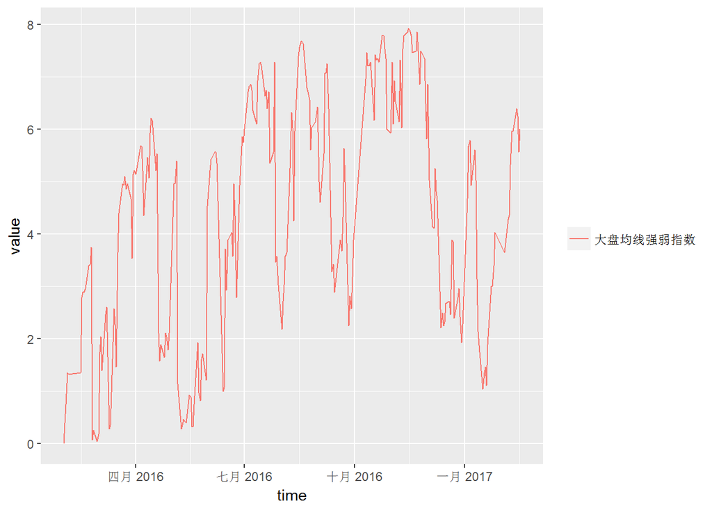

申万一级行业的最新得分见下表：

| 日期 | 指数代码 | 行业 | 最新得分 | 上周得分 |
| --- | --- | --- | --- | --- |
| 2017-02-16 | EI801020 | 采掘 | 8 | 8 |
| 2017-02-16 | EI801030 | 化工 | 8 | 7 |
| 2017-02-16 | EI801040 | 钢铁 | 8 | 8 |
| 2017-02-16 | EI801050 | 有色金属 | 8 | 7 |
| 2017-02-16 | EI801110 | 家用电器 | 8 | 8 |
| 2017-02-16 | EI801120 | 食品饮料 | 8 | 8 |
| 2017-02-16 | EI801160 | 公用事业 | 8 | 7 |
| 2017-02-16 | EI801170 | 交通运输 | 8 | 8 |
| 2017-02-16 | EI801710 | 建筑材料 | 8 | 8 |
| 2017-02-16 | EI801720 | 建筑装饰 | 8 | 8 |
| 2017-02-16 | EI801780 | 银行 | 8 | 8 |
| 2017-02-16 | EI801200 | 商业贸易 | 7 | 6 |
| 2017-02-16 | EI801740 | 国防军工 | 7 | 8 |
| 2017-02-16 | EI801790 | 非银金融 | 7 | 6 |
| 2017-02-16 | EI801880 | 汽车 | 7 | 8 |
| 2017-02-16 | EI801890 | 机械设备 | 7 | 6 |
| 2017-02-16 | EI801140 | 轻工制造 | 6 | 5 |
| 2017-02-16 | EI801080 | 电子 | 5 | 5 |
| 2017-02-16 | EI801130 | 纺织服装 | 5 | 4 |
| 2017-02-16 | EI801150 | 医药生物 | 5 | 4 |
| 2017-02-16 | EI801180 | 房地产 | 5 | 5 |
| 2017-02-16 | EI801730 | 电气设备 | 5 | 5 |
| 2017-02-16 | EI801230 | 综合 | 4 | 4 |
| 2017-02-16 | EI801010 | 农林牧渔 | 3 | 4 |
| 2017-02-16 | EI801770 | 通信 | 3 | 4 |
| 2017-02-16 | EI801210 | 休闲服务 | 2 | 4 |
| 2017-02-16 | EI801750 | 计算机 | 2 | 3 |
| 2017-02-16 | EI801760 | 传媒 | 0 | 1 |

### (c)LLT及均线择时

LLT本质上是一个改进的单均线择时指标，较原始的均线择时延迟更低。  
择时模型和指数本身的净值走势如下图：

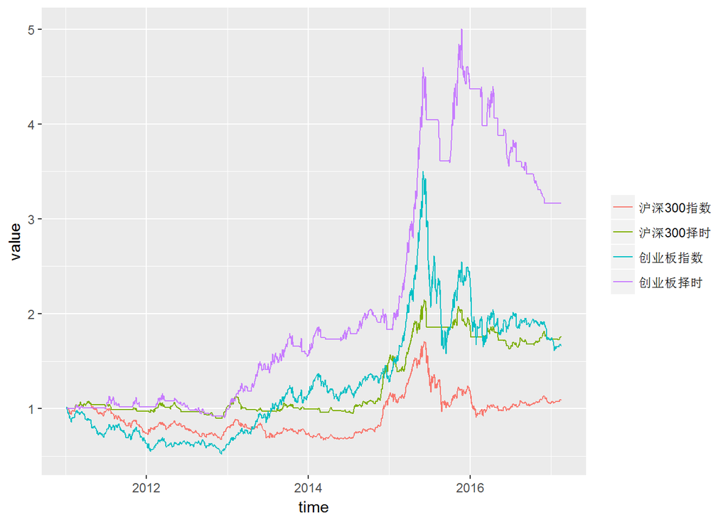

择时模型和指数的收益率统计如下表：

|  | 沪深300指 | 沪深300LLT | 创业板指 | 创业板MA |
| --- | --- | --- | --- | --- |
| 2011-01-04 ~ 2011-12-30 | -25.0% | -2.5% | -35.9% | 1.9% |
| 2012-01-04 ~ 2012-12-31 | 7.6% | 5.4% | -2.1% | -1.7% |
| 2013-01-04 ~ 2013-12-31 | -7.6% | -3.2% | 82.7% | 55.7% |
| 2014-01-02 ~ 2014-12-31 | 51.7% | 52.4% | 12.8% | 17.7% |
| 2015-01-05 ~ 2015-12-31 | 5.6% | 24.3% | 84.4% | 138.1% |
| 2016-01-04 ~ 2016-12-30 | -11.3% | -8.1% | -27.7% | -27.5% |
| 2017-01-03 ~ 2017-02-16 | 4.0% | 1.8% | -3.3% | 0.0% |
| 累计收益率 | 10.0% | 76.5% | 66.8% | 216.7% |
| 年化收益率 | 1.6% | 9.7% | 8.7% | 20.7% |
| 年化波动率 | 24.3% | 15.6% | 33.1% | 22.3% |
| 年化Sharpe值 | 6.4% | 62.4% | 26.3% | 93.0% |
| 最大回撤 | 46.7% | 24.0% | 54.9% | 36.7% |

择时模型最近10个交易日的信号如下表：

| 日期 | 沪深300收盘价 | 沪深300LLT | 沪深300择时信号 | 创业板收盘价 | 创业板MA30 | 创业板择时信号 |
| --- | --- | --- | --- | --- | --- | --- |
| 2017-02-03 | 3364.492 | 3372.750 | hold | 1876.761 | 1932.026 |  |
| 2017-02-06 | 3373.205 | 3372.870 | hold | 1900.447 | 1928.771 |  |
| 2017-02-07 | 3365.685 | 3373.016 | hold | 1889.134 | 1925.728 |  |
| 2017-02-08 | 3383.288 | 3373.477 | hold | 1903.628 | 1923.106 |  |
| 2017-02-09 | 3396.292 | 3374.905 | hold | 1914.082 | 1920.519 |  |
| 2017-02-10 | 3413.487 | 3377.239 | hold | 1904.685 | 1917.799 |  |
| 2017-02-13 | 3436.275 | 3380.752 | hold | 1913.680 | 1916.104 |  |
| 2017-02-14 | 3435.804 | 3384.812 | hold | 1909.395 | 1913.950 |  |
| 2017-02-15 | 3421.713 | 3388.191 | hold | 1892.357 | 1911.408 |  |
| 2017-02-16 | 3440.933 | 3391.563 | hold | 1897.630 | 1909.424 |  |

### (d)网格交易

在经历了三轮股灾，A股逐步回归正常，在过去的一段时间呈现一个震荡的格局，如果未来没有增量信息，很可能维持震荡。结合股指期货的贴水，前期研究了一下网格交易。网格交易的结果如下图：

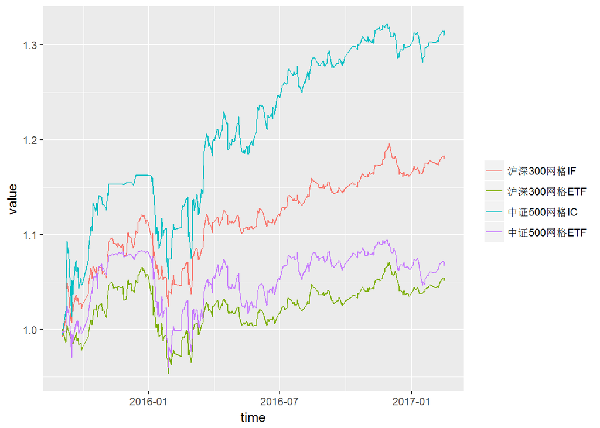

网格交易沪深300股指期货的最新仓位是34.6%，中证500股指期货的最新仓位是38.1%,网格交易的收益统计如下表：

|  | 沪深300指数 | 沪深300网格IF | 沪深300网格ETF | 中证500指数 | 中证500网格IC | 中证500网格ETF |
| --- | --- | --- | --- | --- | --- | --- |
| 2015-09-02 ~ 2015-12-31 | 11.0% | 11.1% | 5.6% | 23.5% | 16.2% | 8.1% |
| 2016-01-04 ~ 2016-12-30 | -11.3% | 4.7% | -1.8% | -17.8% | 11.8% | -1.6% |
| 2017-01-03 ~ 2017-02-16 | 4.0% | 1.7% | 1.7% | 1.5% | 1.2% | 0.7% |
| 累计收益率 | 2.3% | 18.3% | 5.4% | 3.1% | 31.5% | 7.1% |
| 年化收益率 | 1.6% | 12.2% | 3.7% | 2.1% | 20.5% | 4.8% |
| 年化波动率 | 22.6% | 9.4% | 9.2% | 30.4% | 13.9% | 11.8% |
| 年化Sharpe值 | 7.1% | 128.7% | 39.8% | 6.9% | 147.3% | 40.6% |
| 最大回撤 | 26.4% | 8.6% | 10.5% | 33.5% | 9.4% | 11.4% |

## E、选股

### (a)超级小盘股

作为多因子选股的第一部分，有必要从市值因子说起。 下面利用总市值因子，在中证全指的成分股内，选出市值最小的100只股票，这里剔除了ST、新上市、停牌和涨停的股票，100只股票等权配置，每月换仓一次，交易成本千分之三。超级小盘股策略的净值表现如下图。

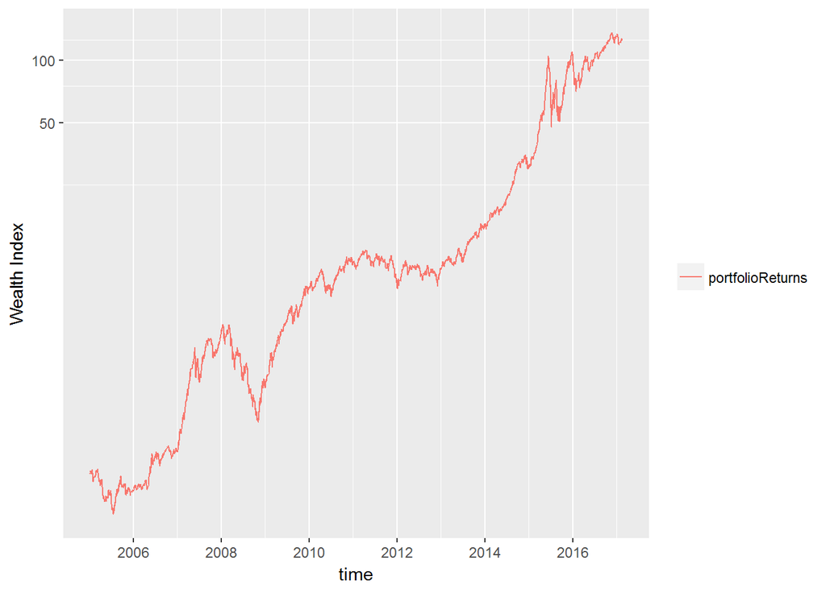

超级小盘股的收益统计如下表：

|  | 超级小盘股 | 沪深300 | 中证500 |
| --- | --- | --- | --- |
| 2005-01-05 ~ 2005-12-30 | -16.7% | -6.0% | -12.8% |
| 2006-01-04 ~ 2006-12-29 | 55.8% | 121.0% | 100.7% |
| 2007-01-04 ~ 2007-12-28 | 265.1% | 161.5% | 186.6% |
| 2008-01-02 ~ 2008-12-31 | -44.5% | -65.9% | -60.8% |
| 2009-01-05 ~ 2009-12-31 | 205.8% | 96.7% | 131.3% |
| 2010-01-04 ~ 2010-12-31 | 32.2% | -12.5% | 10.5% |
| 2011-01-04 ~ 2011-12-30 | -19.4% | -25.0% | -33.8% |
| 2012-01-04 ~ 2012-12-31 | 15.3% | 7.6% | 0.3% |
| 2013-01-04 ~ 2013-12-31 | 63.3% | -7.6% | 16.9% |
| 2014-01-02 ~ 2014-12-31 | 88.8% | 51.7% | 39.0% |
| 2015-01-05 ~ 2015-12-31 | 254.4% | 5.6% | 43.1% |
| 2016-01-04 ~ 2016-12-30 | 21.2% | -11.3% | -17.8% |
| 2017-01-03 ~ 2017-02-16 | -3.3% | 4.0% | 1.5% |
| 累计收益率 | 12544.6% | 250.1% | 546.6% |
| 年化收益率 | 49.1% | 10.9% | 16.6% |
| 年化波动率 | 35.9% | 28.5% | 32.6% |
| 年化Sharpe值 | 136.8% | 38.2% | 51.1% |
| 最大回撤 | 66.3% | 72.3% | 72.4% |

### (b)银行股轮动

银行股轮动是参考集思录的热门贴银行股评级而来的，数据的提取和参数的设置和原贴有一定的差别，所以轮动的效果也会不太一样，不过回测的效果还不错，从现在开始跟踪。2013年以来银行股轮动的结果如下图：

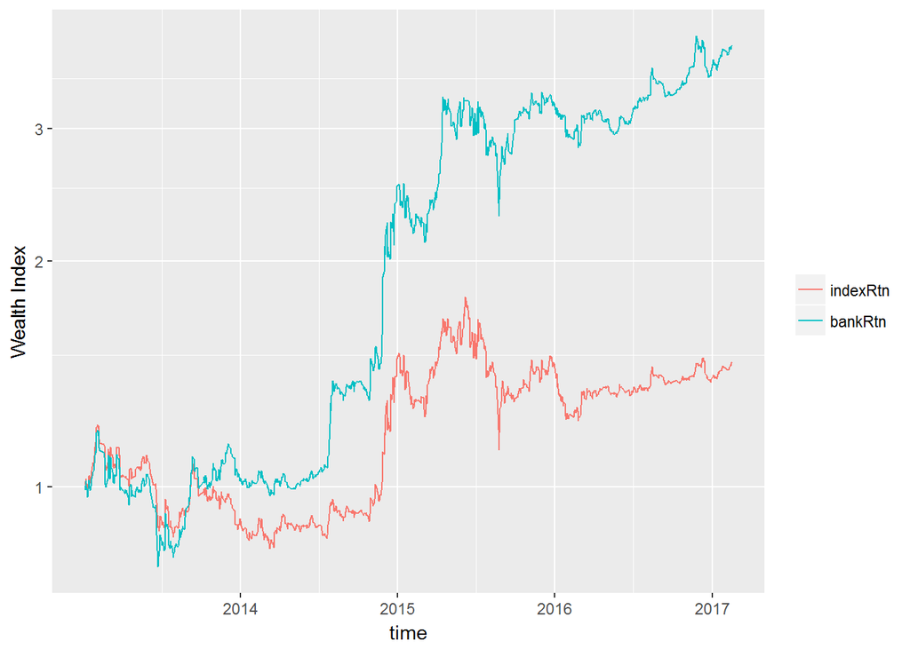

银行股轮动的收益统计如下表：

|  | 申万银行 | 银行股轮动 |
| --- | --- | --- |
| 2013-01-04 ~ 2013-12-31 | -9.2% | 3.0% |
| 2014-01-02 ~ 2014-12-31 | 63.2% | 144.5% |
| 2015-01-05 ~ 2015-12-31 | -1.4% | 29.0% |
| 2016-01-04 ~ 2016-12-30 | -4.9% | 10.5% |
| 2017-01-03 ~ 2017-02-16 | 5.6% | 8.0% |
| 累计收益率 | 46.8% | 287.8% |
| 年化收益率 | 9.7% | 38.9% |
| 年化波动率 | 28.6% | 32.5% |
| 年化Sharpe值 | 34.1% | 119.7% |
| 最大回撤 | 37.4% | 34.2% |

银行股轮动的最新得分如下表：

| 日期 | 代码 | 简称 | PB | 预期ROE | 翻倍期 | 持仓 |
| --- | --- | --- | --- | --- | --- | --- |
| 2017-02-16 | EQ601818 | 光大银行 | 0.78 | 0.12 | 3.9 |  |
| 2017-02-16 | EQ600015 | 华夏银行 | 0.84 | 0.15 | 3.9 | hold |
| 2017-02-16 | EQ601328 | 交通银行 | 0.74 | 0.10 | 4.0 |  |
| 2017-02-16 | EQ601988 | 中国银行 | 0.78 | 0.11 | 4.2 |  |
| 2017-02-16 | EQ601288 | 农业银行 | 0.82 | 0.12 | 4.2 |  |
| 2017-02-16 | EQ000001 | 平安银行 | 0.82 | 0.12 | 4.3 |  |
| 2017-02-16 | EQ601398 | 工商银行 | 0.86 | 0.13 | 4.5 |  |
| 2017-02-16 | EQ601166 | 兴业银行 | 0.93 | 0.14 | 4.6 |  |
| 2017-02-16 | EQ601939 | 建设银行 | 0.95 | 0.14 | 5.0 |  |
| 2017-02-16 | EQ600000 | 浦发银行 | 1.01 | 0.14 | 5.2 |  |
| 2017-02-16 | EQ600016 | 民生银行 | 1.02 | 0.13 | 6.0 |  |
| 2017-02-16 | EQ601169 | 北京银行 | 1.09 | 0.14 | 6.2 |  |
| 2017-02-16 | EQ601009 | 南京银行 | 1.19 | 0.15 | 6.2 |  |
| 2017-02-16 | EQ600036 | 招商银行 | 1.22 | 0.15 | 6.4 |  |
| 2017-02-16 | EQ601998 | 中信银行 | 1.01 | 0.11 | 6.6 |  |
| 2017-02-16 | EQ002142 | 宁波银行 | 1.43 | 0.16 | 7.1 |  |
| 2017-02-16 | EQ601997 | 贵阳银行 | 1.95 | 0.17 | 8.6 |  |
| 2017-02-16 | EQ600919 | 江苏银行 | 1.47 | 0.13 | 8.9 |  |
| 2017-02-16 | EQ601229 | 上海银行 | 1.41 | 0.12 | 9.1 |  |
| 2017-02-16 | EQ600926 | 杭州银行 | 1.65 | 0.11 | 11.9 |  |
| 2017-02-16 | EQ601128 | 常熟银行 | 2.66 | 0.10 | 16.9 |  |
| 2017-02-16 | EQ600908 | 无锡银行 | 2.61 | 0.10 | 17.4 |  |
| 2017-02-16 | EQ603323 | 吴江银行 | 2.64 | 0.08 | 21.6 |  |
| 2017-02-16 | EQ002807 | 江阴银行 | 3.34 | 0.09 | 21.7 |  |